# Weather Data Project

Rebecca Sullivan

5/6/2022

# About

This analysis focuses on weather that can lead to car batteries not holding enough charge to start a car (ie. dead car batteries). Both extreme heat and extreme cold can put stress on a car battery and cause it to not hold enough charge to power an ignition start. The goal is to anticipate the need to batteries and jump start services in the right locations.

Car batteries recharge slower below 32 degrees F and high temperatures reduce the life of a battery (every 15 degrees F over 77, battery life is cut in half).

Weather stations with temperature readings were needed in different parts of the USA. Four stations were selected that had the needed information. And they can all be serviced by the same battery and jump start service entity. Finding weather stations with temperature data was more of a challenge then anticipated. Though most weather reports include high and low forecast temperatures, the available data often only had wind speed and precipitation. Custom data was requested from NOAA for stations that should include temperature readings.

## Question

- Are there differences in the temperature trends in these 4 areas of the country that indicate supplies and staffing trends should be different throughout the year?

# Data

### Csv files were requested from the National Oceanic and Atmospheric Administration data page: https://www.ncdc.noaa.gov/cdo-web/

```r
weather_1 <- read_csv(here::here("Data", "2938751.csv")) %>%
  select (STATION, NAME, LATITUDE, LONGITUDE,  ELEVATION, DATE, PRCP, SNOW, TMAX, TMIN  )

weather_3 <- read_csv(here::here("Data", "2966466.csv")) %>%
  select (STATION, NAME, LATITUDE, LONGITUDE,  ELEVATION, DATE, PRCP, SNOW, TMAX, TMIN  )


weather <- union (weather_1, weather_3) %>%
  mutate (Location = NAME ,
          Year = year(DATE),
          Month = months(DATE),
          Month_num = month(DATE, label = FALSE) ,
          Quarter = quarters(DATE),
          Daily_Temp_Change = TMAX - TMIN  ) %>%
  #flags to indicate extreme hot or cold temps
  mutate( cold_flag = if_else(condition = TMIN <= 32,
                                  true = T,
                                  false = F,
                              missing = NA)  ,
           hot_flag = if_else(condition = TMAX >= 90,
                                  true = T,
                                  false = F,
                              missing = NA))  %>%
  #comparing the temperature change over multiples days
  mutate( Temp_1Week_diff = abs(TMIN  - lag(TMAX, n = 7)),
          Temp_2day_diff = abs(TMIN - lag(TMAX , n=1)))  %>%
  filter(Year %in% c(2019, 2020, 2021))
```

```r
weather %>%
  count(STATION, LATITUDE, LONGITUDE, ELEVATION, Location)
```

```
## # A tibble: 4 x 6
##   STATION     LATITUDE LONGITUDE ELEVATION Location                            n
##   <chr>          <dbl>     <dbl>     <dbl> <chr>                           <int>
## 1 USC00396427     44.1    -103.     1439.  PACTOLA DAM, SD US               1096
## 2 USW00013739     39.9     -75.2       2.1 PHILADELPHIA INTERNATIONAL AIR~  1096
## 3 USW00013967     35.4     -97.6     390.  OKLAHOMA CITY WILL ROGERS WORL~  1096
## 4 USW00093812     39.1     -84.4     145.  CINCINNATI MUNICIPAL AIRPORT L~  1096
```

```r
weather %>%
  count(Location, Year)
```

```
## # A tibble: 12 x 3
##    Location                                          Year     n
##    <chr>                                            <dbl> <int>
##  1 CINCINNATI MUNICIPAL AIRPORT LUNKEN FIELD, OH US  2019   365
##  2 CINCINNATI MUNICIPAL AIRPORT LUNKEN FIELD, OH US  2020   366
##  3 CINCINNATI MUNICIPAL AIRPORT LUNKEN FIELD, OH US  2021   365
##  4 OKLAHOMA CITY WILL ROGERS WORLD AIRPORT, OK US    2019   365
##  5 OKLAHOMA CITY WILL ROGERS WORLD AIRPORT, OK US    2020   366
##  6 OKLAHOMA CITY WILL ROGERS WORLD AIRPORT, OK US    2021   365
##  7 PACTOLA DAM, SD US                                2019   365
##  8 PACTOLA DAM, SD US                                2020   366
##  9 PACTOLA DAM, SD US                                2021   365
## 10 PHILADELPHIA INTERNATIONAL AIRPORT, PA US         2019   365
## 11 PHILADELPHIA INTERNATIONAL AIRPORT, PA US         2020   366
## 12 PHILADELPHIA INTERNATIONAL AIRPORT, PA US         2021   365
```

Temperature measures are available for the state of SD, OK, OH and PA. Only full year data will be used, for 2019, 2020 and 2021.

Note that the PA and OH stations have similar Latitude, but not elevation.

# Temperature Variation

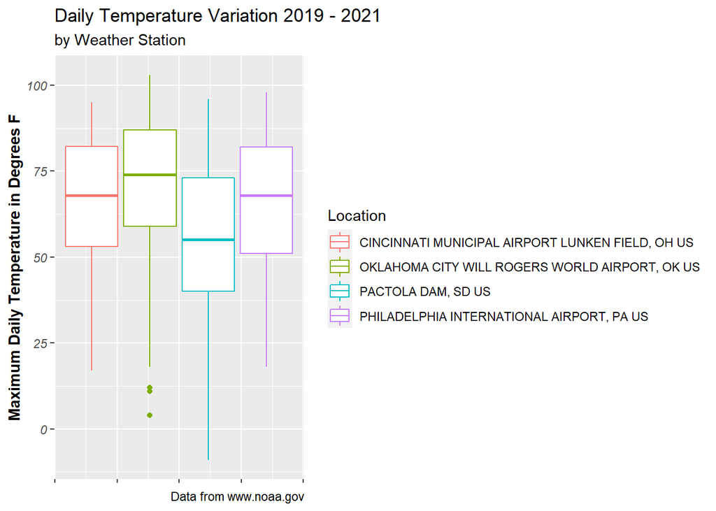

```r
weather %>%
  ggplot(aes ( y = TMAX ,
               group = Location,
               color = Location)) +
  geom_boxplot(na.rm = T )    +
  labs(
        y = "Maximum Daily Temperature in Degrees F" ,
    title = "Daily Temperature Variation 2019 - 2021" ,
    subtitle = "by Weather Station",
    caption = "Data from www.noaa.gov") +
    theme_gray()  +
    theme(axis.title = element_text(face = "bold"),
        axis.text = element_text(face = "italic") ,
         axis.text.x = element_blank( ) )
```

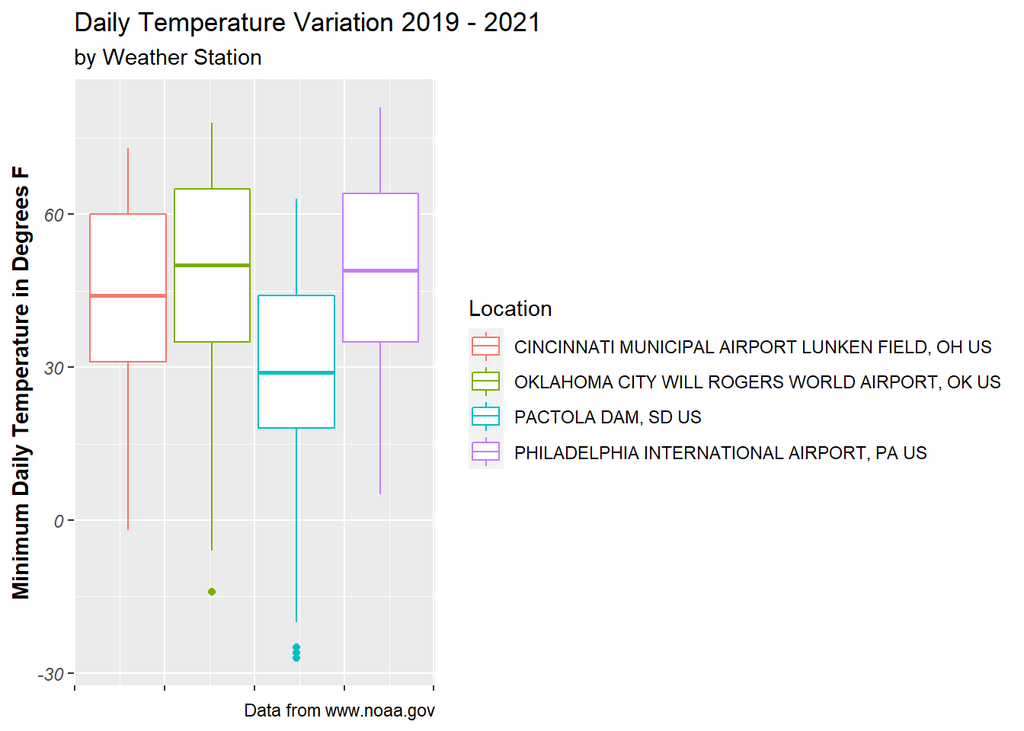

```r
weather %>%
  ggplot(aes ( y = TMIN,
               group = Location,
               color = Location)) +
  geom_boxplot(na.rm = T ) +
      labs(
        y = "Minimum Daily Temperature in Degrees F" ,
    title = "Daily Temperature Variation 2019 - 2021" ,
    subtitle = "by Weather Station",
    caption = "Data from www.noaa.gov") +
    theme_gray()  +
    theme(axis.title = element_text(face = "bold"),
        axis.text = element_text(face = "italic") ,
        axis.text.x = element_blank( ) )
```

# Variation over Time

## Daily Differences

### Max and Min Trend

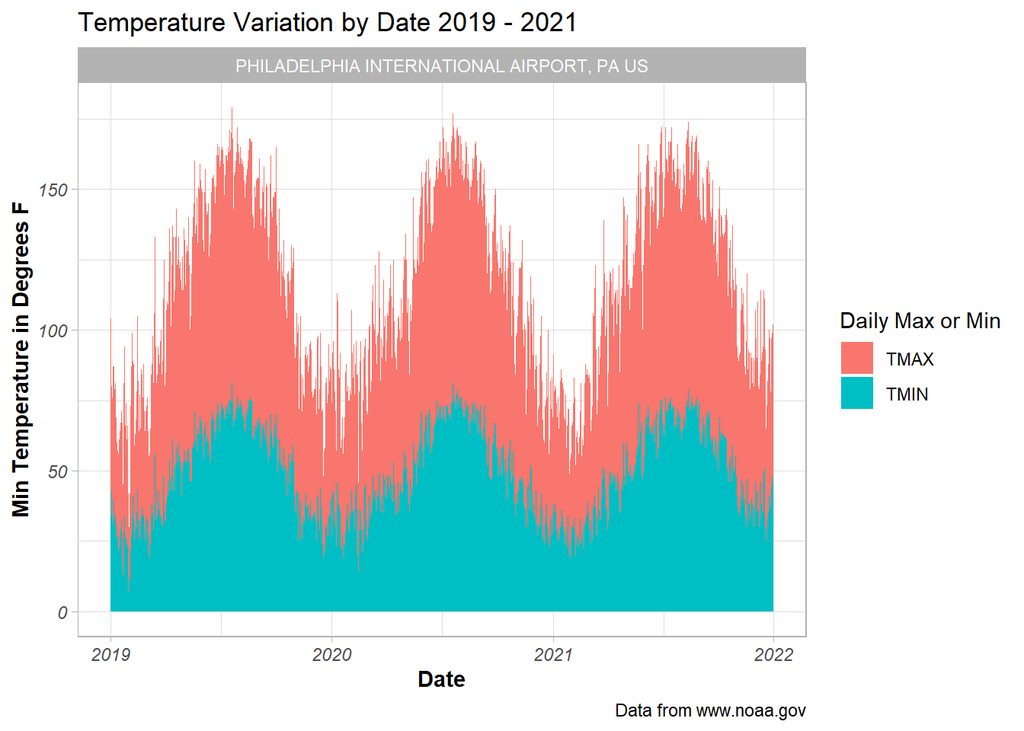

```r
weather %>%
graph_temps(Station_code ="USW00013739")
```

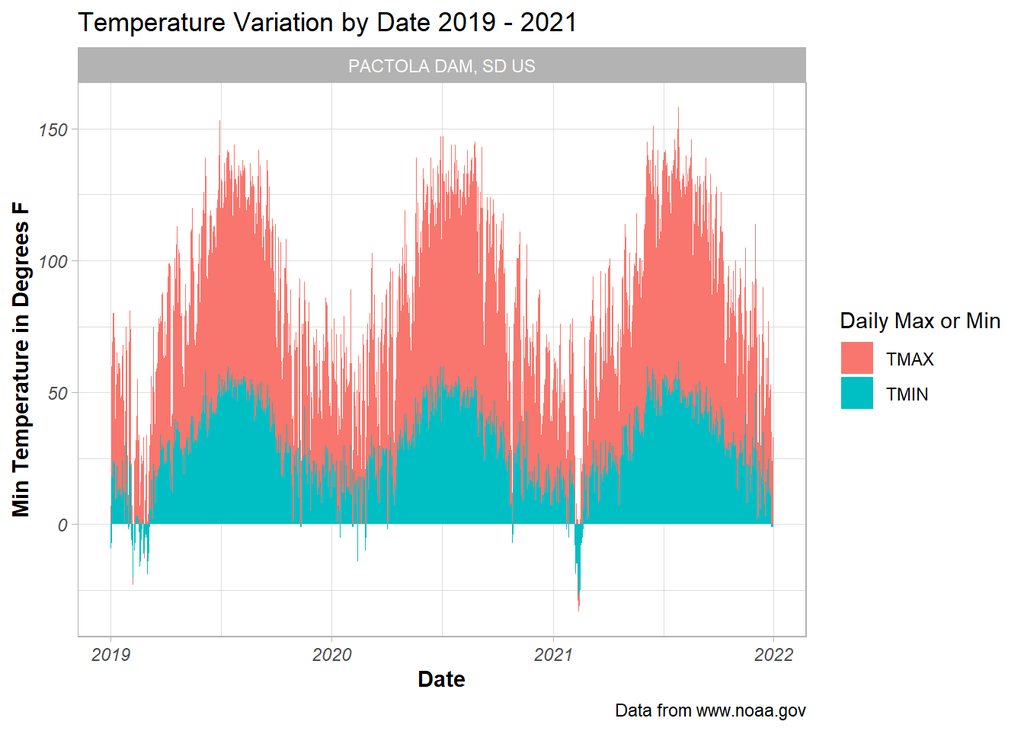

```r
weather %>%
graph_temps(Station_code ="USC00396427")
```

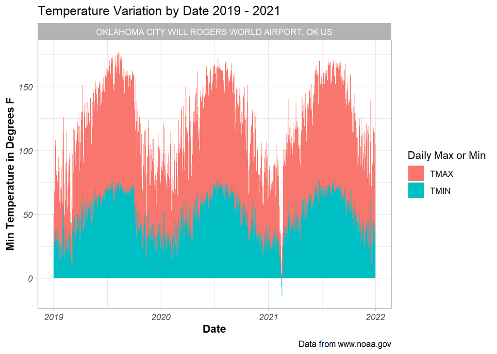

```r
weather %>%
graph_temps(Station_code ="USW00013967")
```

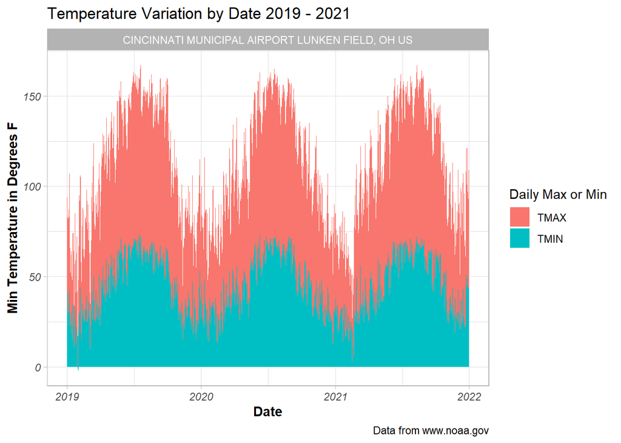

```r
weather %>%
graph_temps(Station_code ="USW00093812")
```

Since the temperatures are stacked, only the minimum temperature can be easily read from the graph. But the trends are clear for both min and max temperatures. Looking at each station individually, the high and low temperatures do seem to cycle with the seasons. Not seeing anything in the past 3 years that shows highs and lows don’t follow the same general pattern. But there are min temperatures below 32 and highs above 90. Those facts together in the same year contribute to battery wear and dead batteries.

### Daily Temp Change

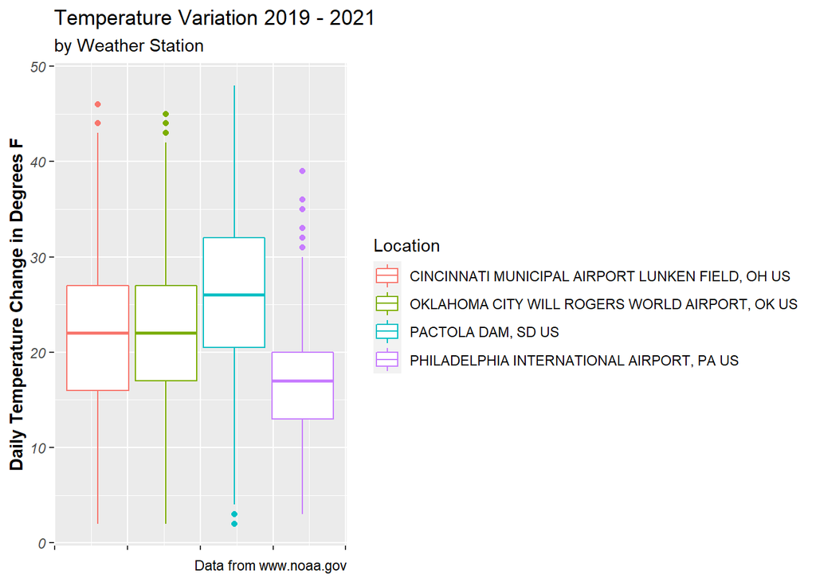

```r
weather %>%
  ggplot(aes ( y = Daily_Temp_Change,
               group = Location,
               color = Location)) +
  geom_boxplot(na.rm = T ) +
  labs(
        y = "Daily Temperature Change in Degrees F" ,
    title = "Temperature Variation 2019 - 2021" ,
    subtitle = "by Weather Station",
    caption = "Data from www.noaa.gov") +
    theme_gray()  +
    theme(axis.title = element_text(face = "bold"),
        axis.text = element_text(face = "italic") ,
        axis.text.x = element_blank( ) )
```

The difference between the max and min temperature for any day is 20 - 30 degrees on average, except for the PA station which is even smaller. None of the measures, even the outliers, were more than 50 degrees difference. So we will not see any days where the max is above 90 and the low is below 32. However, the next metric to check is if that could occur over 2 consecutive days, or over a week.

### Change over 2 days and 7 days

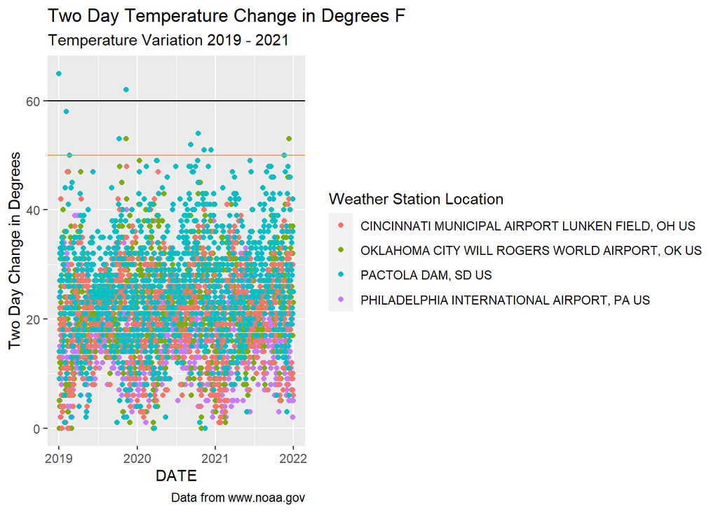

```r
weather %>%
  ggplot(aes( x = DATE,
              y =Temp_2day_diff,
              color = Location)) +
  geom_point(na.rm = TRUE) +
  geom_hline( aes(yintercept = 60)) +
  geom_hline( aes(yintercept = 50) ,
              color = "orange") +
  theme_gray() +
  labs(
        y = "Two Day Change in Degrees" ,
    title = "Two Day Temperature Change in Degrees F" ,
    subtitle = "Temperature Variation 2019 - 2021",
    color = "Weather Station Location",
    caption = "Data from www.noaa.gov")
```

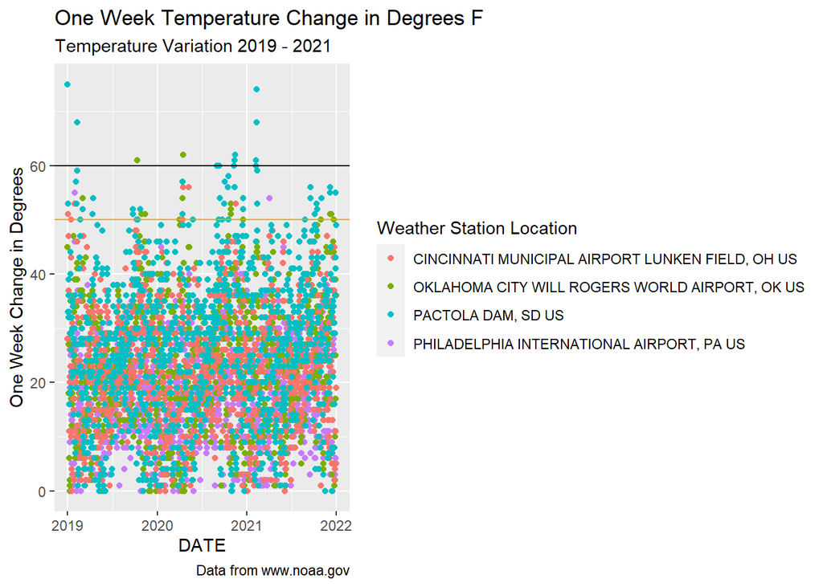

```r
weather %>%
  ggplot(aes( x = DATE,
              y =Temp_1Week_diff,
              color = Location)) +
  geom_point(na.rm = TRUE) +
  geom_hline( aes(yintercept = 60)) +
  geom_hline( aes(yintercept = 50),
              color = "orange") +
  theme_gray() +
    labs(
        y = "One Week Change in Degrees" ,
    title = "One Week Temperature Change in Degrees F" ,
    subtitle = "Temperature Variation 2019 - 2021",
    color = "Weather Station Location",
    caption = "Data from www.noaa.gov")
```

South Dakota and Oklahoma weather stations had more of the weather trends where the high and low over several days were far enough apart to cause extra battery stress. The other 2 stations did have a few such trends, but based on this SD and OK are places to check into futher and prepare for more battery wear.

# Number of Extreme Temp Days

## Per Station, Per Year

```r
weather %>%
  count(cold_flag, hot_flag)
```

```
## # A tibble: 4 x 3
##   cold_flag hot_flag     n
##   <lgl>     <lgl>    <int>
## 1 FALSE     FALSE     2615
## 2 FALSE     TRUE       412
## 3 TRUE      FALSE     1356
## 4 NA        FALSE        1
```

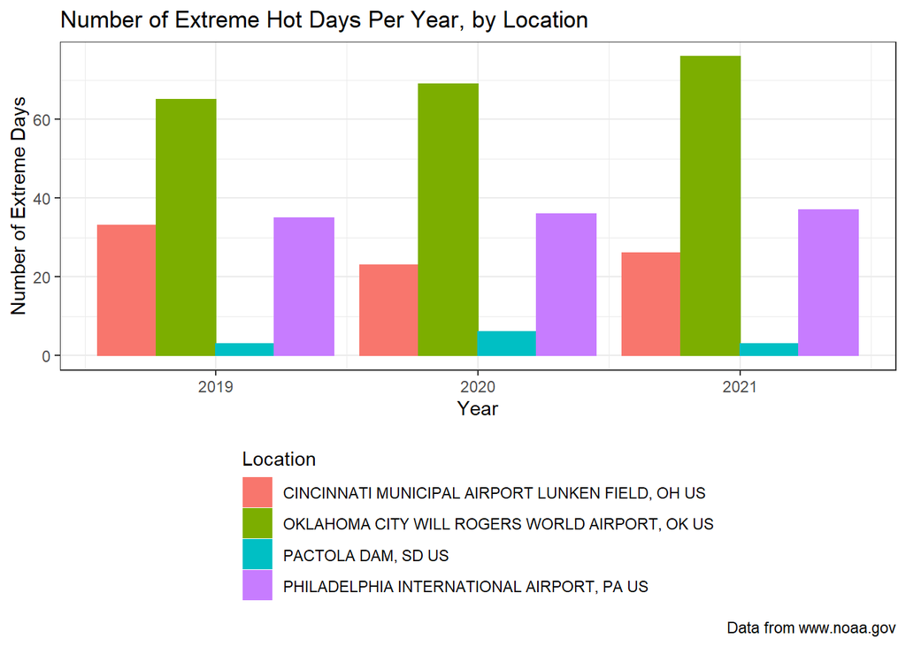

```r
weather %>%
    group_by(Location, Year) %>%
  summarise( num_hot_days = sum(as.numeric(hot_flag)),
             num_cold_days = sum(as.numeric(cold_flag))) %>%
  ungroup() %>%
  ggplot( aes ( x =Year ,
                 y=  num_hot_days,
                color = Location,
                fill = Location)) +
  geom_col(position = "dodge") +
  theme_bw() +
  theme(legend.position = "bottom" ,
        legend.direction = "vertical") +
      labs(
        y = "Number of Extreme Days" ,
    title = "Number of Extreme Hot Days Per Year, by Location" ,
    caption = "Data from www.noaa.gov")
```

Based on the previous graphs, the extreme hot flag and extreme cold flag are not expected on the same day. But when looking at the number of extreme hot days, OK has the most. The PA and OH have the next highest count for hot days. More data will be needed to determine if those 2 areas should be treated the same, but the OK area is clearly different.

[figure not shown]

```r
weather %>%
  group_by(Location, Year) %>%
  summarise( num_hot_days = sum(as.numeric(hot_flag)),
             num_cold_days = sum(as.numeric(cold_flag))) %>%
  ungroup() %>%
  ggplot( aes ( x =Year ,
                 y=  num_cold_days,
                color = Location,
                fill = Location)) +
  geom_col(position = "dodge") +
  theme_bw() +
  theme(legend.position = "bottom" ,
        legend.direction = "vertical") +
      labs(
        y = "Number of Extreme Days" ,
    title = "Number of Extreme Hot Days Per Year, by Location" ,
    caption = "Data from www.noaa.gov")
```

The SD and OK stations need to be checked based on 1 extreme day, The OH station does not have the highest or lowest temperatures, but there is enough variation between hot and cold that there could be more need for batteries there.

## Timing During the Year

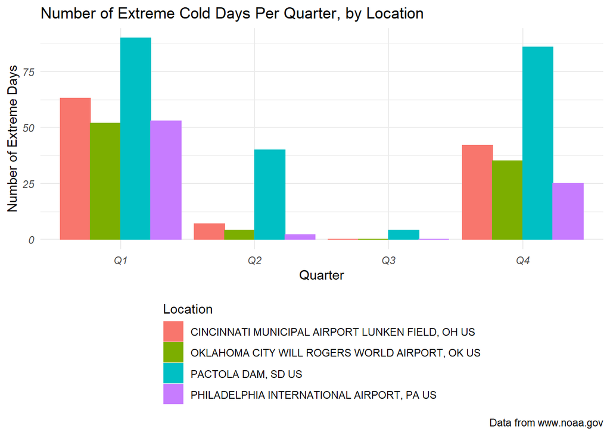

```r
weather %>%
  group_by(Location, Year, Quarter ) %>%
  summarise( num_hot_days = sum(as.numeric(hot_flag)),
             num_cold_days = sum(as.numeric(cold_flag))) %>%
  ungroup() %>%
  ggplot( aes ( x = Quarter,
                 y=  num_cold_days,
                color = Location,
                fill = Location) ) +
  geom_col(position = "dodge", na.rm = TRUE) +
  theme_minimal() +
  theme(legend.position = "bottom" ,
        legend.direction = "vertical",
        axis.text = element_text(face = "italic") ) +
  labs(
        y = "Number of Extreme Days" ,
    title = "Number of Extreme Cold Days Per Quarter, by Location" ,
    caption = "Data from www.noaa.gov")
```

Only SD had a significant number of cold days in Q2. All stations had extreme temperatures in Q1, and most have at least a trend for cold days in Q4.

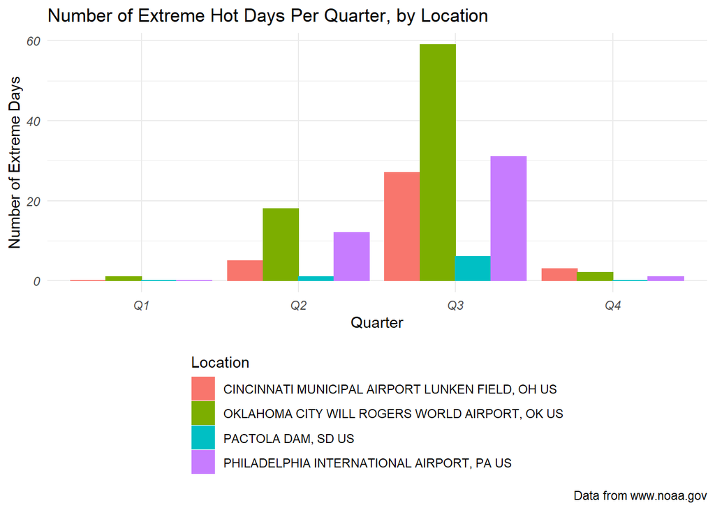

```r
weather %>%
  group_by(Location, Year, Quarter ) %>%
  summarise( num_hot_days = sum(as.numeric(hot_flag)),
             num_cold_days = sum(as.numeric(cold_flag))) %>%
  ungroup() %>%
  ggplot( aes ( x = Quarter,
                 y=  num_hot_days,
                color = Location,
                fill = Location) ) +
  geom_col(position = "dodge", na.rm = TRUE) +
  theme_minimal() +
  theme(legend.position = "bottom" ,
        legend.direction = "vertical",
        axis.text = element_text(face = "italic") ) +
  labs(
        y = "Number of Extreme Days" ,
    title = "Number of Extreme Hot Days Per Quarter, by Location" ,
    caption = "Data from www.noaa.gov")
```

Q3 is where most stations see their hottest days. the OK and PA stations also had hot days in Q2. This again shows that not all the areas have the same weather timing, at least not for the temperatures which can damage car batteries.

# Correlation

## Between area and temperature

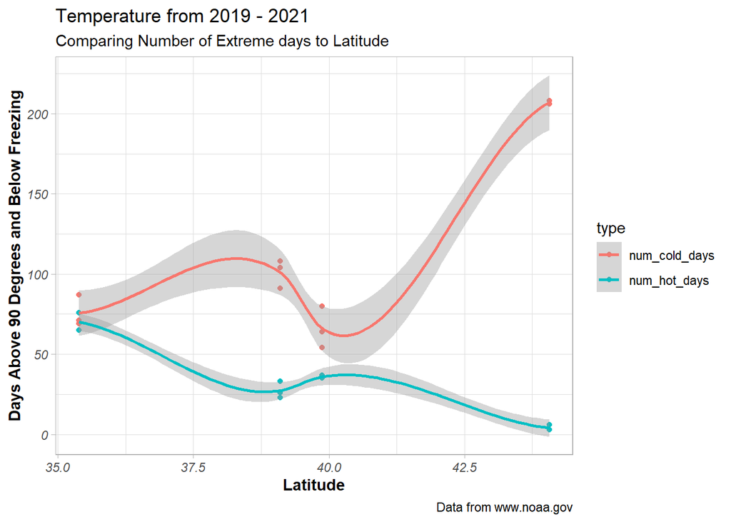

```r
weather %>%
  group_by(STATION,LATITUDE, Year) %>%
  summarise( num_hot_days = sum(as.numeric(hot_flag)),
             num_cold_days = sum(as.numeric(cold_flag))) %>%
  pivot_longer( starts_with("num_"),
               names_to = "type" ) %>%
  ungroup() %>%
  ggplot( aes ( x = LATITUDE,
                y = value,
                color = type
               )) +
  geom_point() +
  geom_smooth(na.rm = TRUE) +
  labs(
            x = "Latitude" ,
        y = "Days Above 90 Degrees and Below Freezing" ,
    title = "Temperature from 2019 - 2021" ,
    subtitle = "Comparing Number of Extreme days to Latitude",
    caption = "Data from www.noaa.gov") +
    theme_light()  +
    theme(axis.title = element_text(face = "bold"),
        axis.text = element_text(face = "italic")  )
```

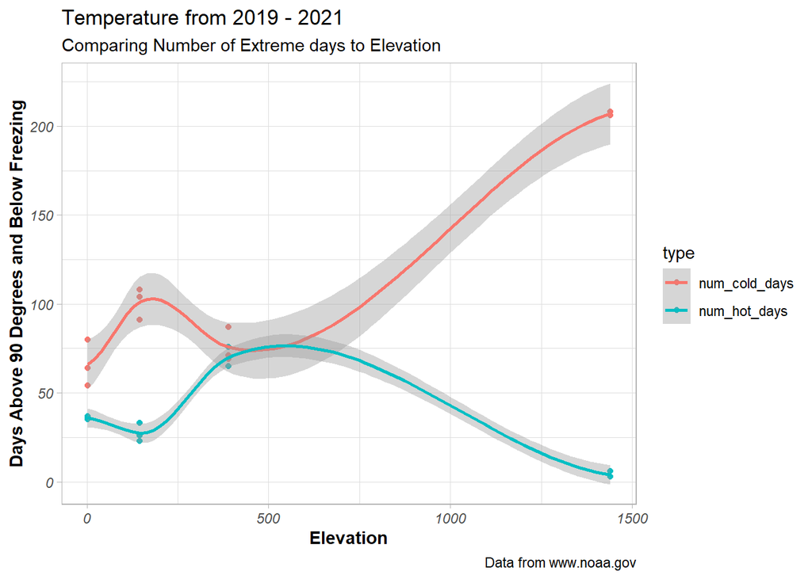

```r
weather %>%
  group_by(STATION,ELEVATION, Year) %>%
  summarise( num_hot_days = sum(as.numeric(hot_flag)),
             num_cold_days = sum(as.numeric(cold_flag))) %>%
  pivot_longer( starts_with("num_"),
               names_to = "type" ) %>%
  ungroup() %>%
  ggplot( aes ( x = ELEVATION,
                y = value,
                color = type
               )) +
  geom_point() +
  geom_smooth(na.rm = TRUE) +
  labs(
            x = "Elevation" ,
        y = "Days Above 90 Degrees and Below Freezing" ,
    title = "Temperature from 2019 - 2021" ,
    subtitle = "Comparing Number of Extreme days to Elevation",
    caption = "Data from www.noaa.gov") +
    theme_light()  +
    theme(axis.title = element_text(face = "bold"),
        axis.text = element_text(face = "italic")  )
```

These weather stations where in different parts of the country, so they were not expected to all follow the same trends.Several characteristics about the 4 areas were compared. It appears that the Latitude and the Elevation may have a larger effect on temperature trends.

# Conclusion

There are enough differences in high and low temperatures trends that show that car batteries may fail at different rates and at different times in those 4 areas of the country.

# Next Steps

Use more data points to determine if the patterns above are trends or just outliers.

- Acquire more temperature readings from the 4 states already listed
  - Use the same Time Frame
  - Explore other data sources besides NOAA
  - this will help show if trends in 2019 - 2021 are reproducible
- Gather data from the same stations from earlier years: 1979 - 1981, 1998 - 1991, 1999 - 2001
  - Add these to the current analysis and check if the same patterns hold
  - View each decade separately and check for different patterns
  - This will show if the areas were different over time, and show if there have been changes since 1979
- Gather battery sales data and jump start data
  - Check if the trends in OK, SD and OH followed the extreme hot and cold days
  - Adjust resource plan for each area according to the weather and battery trends